# Juvenile Snowshoe Hares in Bonanza Creek Experimental Forest

By: Mikel Irigoyen

### 1. Introduction

This report shows a conscientious overview of differences in juvenile hare weight within the Bonanza Creek Experimental Forest from 1998 - 2012 (Kielland et al. 1999). Specifically, differences between male and female hares and assessing if weight correlates to hindfoot length.

### 2. Data and Analyses

Data on trapped hares including site, weight, and hindfoot length was provided by Bonanza Creek Long Term Ecological Research Network (LTER), which is located in the boreal forest of interior Alaska. Over 300 juvenile hares were trapped over a span of 14 years (1998 - 2012). Following exploratory data visualization, weights of male and female hares are looked at using a two-sample t-test. Differences between groups are described by Cohen’s *d* effect size. The relationship between weight and hindfoot length explored by simple linear regression. All analyses are in R version 4.0.2 using RStudio version 1.3.1073.

### 3. Exploratory Findings

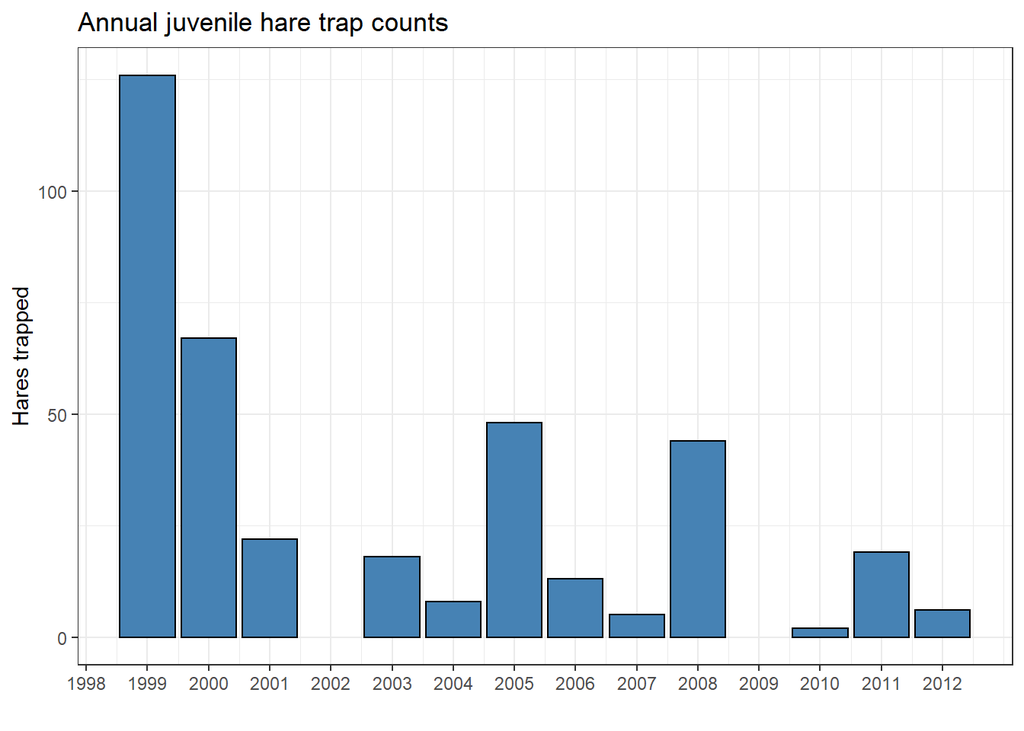

```
## # A tibble: 12 x 2
##    year_updated average
##           <dbl>   <dbl>
##  1         1999     126
##  2         2000      67
##  3         2001      22
##  4         2003      18
##  5         2004       8
##  6         2005      48
##  7         2006      13
##  8         2007       5
##  9         2008      44
## 10         2010       2
## 11         2011      19
## 12         2012       6
```

**Figure.1** Amount of juvenile hares trapped annually between 1998 - 2012 at all sites. There is a large amount of variability in hares trapped year to year. With the highest number or trapped hares occurring in 1999 (126) and multiple years (1998,2002,2009) showing zero juvenile hares trapped. There may be variability in days spent trapping year to year. To remedy this inconsistency, it may prove prudent to standardize the amount of days spent trapping and time of year moving forward.

## visualize juvenile hair weights

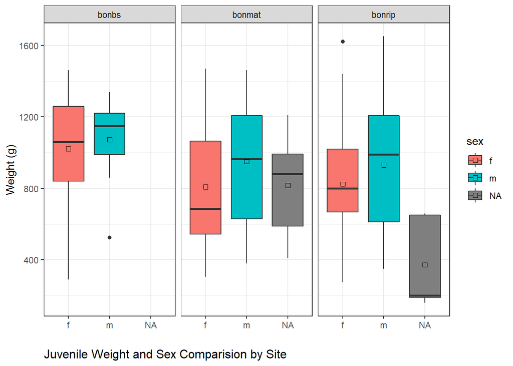

## Juvenile weight comparison (male & female snowshoe hares).

Juvenile weight comparison

| Sex | Mean (g) | SD (g) | Sample Size |
| --- | --- | --- | --- |
| f | 855.3909 | 292.2526 | 197 |
| m | 945.8589 | 333.2151 | 163 |

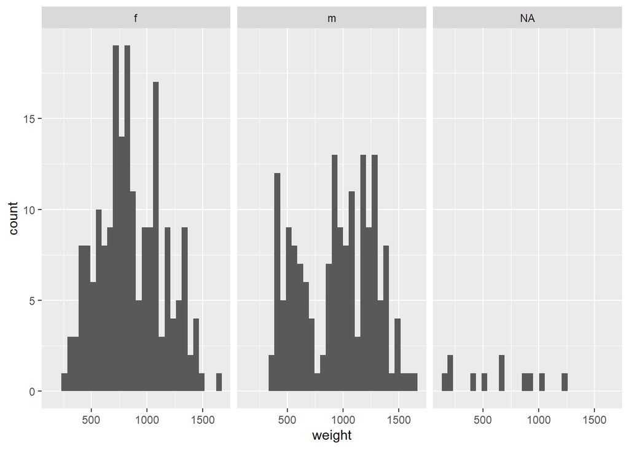

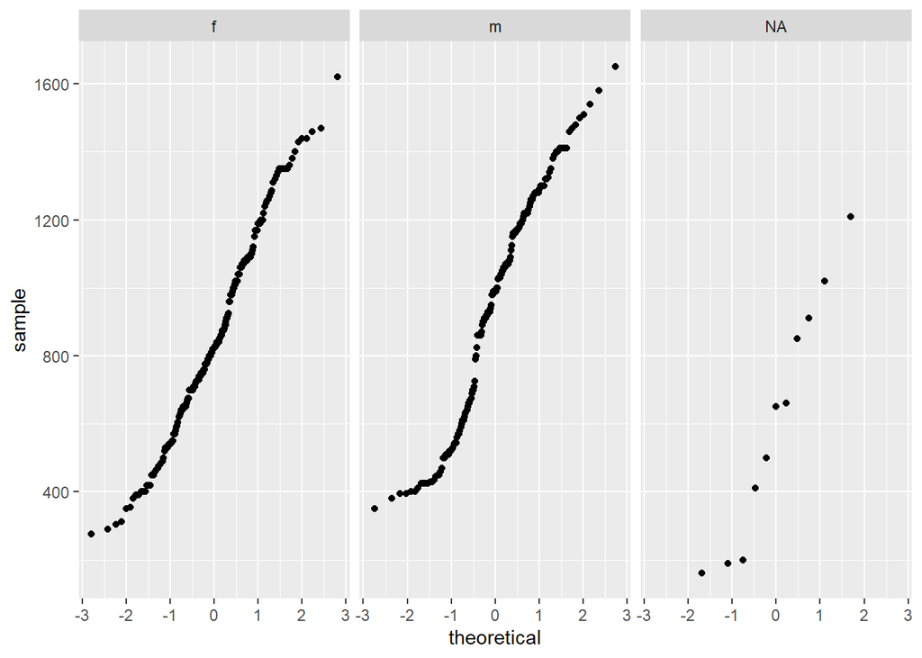

## Relationship between juvenile weight & hind foot length.

[figure not shown]